# W3cubDocs

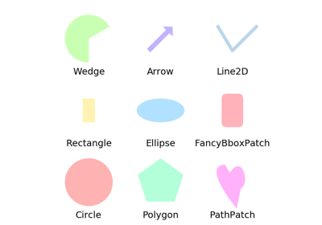

[Reference for Matplotlib artists](https://matplotlib.org/3.1.1/gallery/shapes_and_collections/artist_reference.html#sphx-glr-gallery-shapes-and-collections-artist-reference-py)

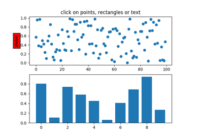

[Pick Event Demo](https://matplotlib.org/3.1.1/gallery/event_handling/pick_event_demo.html#sphx-glr-gallery-event-handling-pick-event-demo-py)

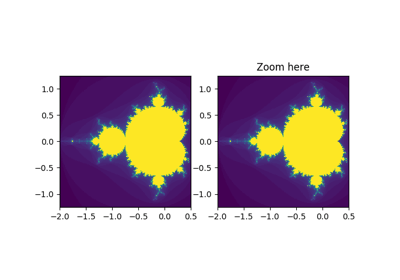

[Viewlims](https://matplotlib.org/3.1.1/gallery/event_handling/viewlims.html#sphx-glr-gallery-event-handling-viewlims-py)

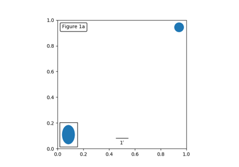

[Anchored Artists](https://matplotlib.org/3.1.1/gallery/misc/anchored_artists.html#sphx-glr-gallery-misc-anchored-artists-py)

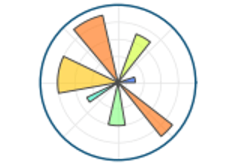

[Matplotlib logo](https://matplotlib.org/3.1.1/gallery/misc/logos2.html#sphx-glr-gallery-misc-logos2-py)

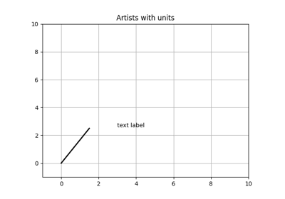

[Artist tests](https://matplotlib.org/3.1.1/gallery/units/artist_tests.html#sphx-glr-gallery-units-artist-tests-py)

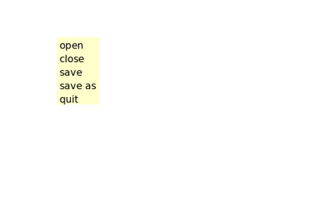

[Menu](https://matplotlib.org/3.1.1/gallery/widgets/menu.html#sphx-glr-gallery-widgets-menu-py)

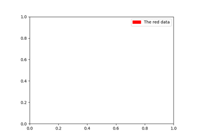

[Legend guide](https://matplotlib.org/3.1.1/tutorials/intermediate/legend_guide.html#sphx-glr-tutorials-intermediate-legend-guide-py)

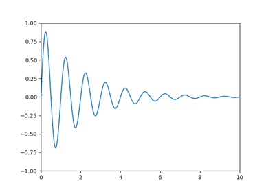

[Transformations Tutorial](https://matplotlib.org/3.1.1/tutorials/advanced/transforms_tutorial.html#sphx-glr-tutorials-advanced-transforms-tutorial-py)

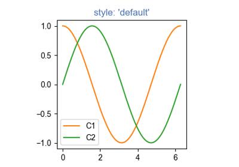

[Specifying Colors](https://matplotlib.org/3.1.1/tutorials/colors/colors.html#sphx-glr-tutorials-colors-colors-py)

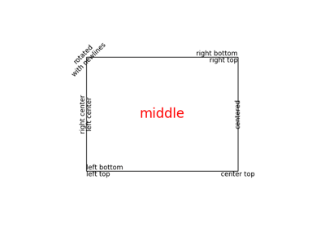

[Text properties and layout](https://matplotlib.org/3.1.1/tutorials/text/text_props.html#sphx-glr-tutorials-text-text-props-py)